[figure not shown]

# Préparation CCF E5.2 : Aide à la navigation

Ce système sera utilisé dans le cadre de l’épreuve de CCF E5.2 qui se déroulera courant janvier 2017.

## Présentation

Le système d’“Aide à la navigation” est capable de commander des équipements (hélice d’étrave, …) installés sur un bateau et d’afficher des informations (hauteur de fond, …) liées à sa navigation.

[figure not shown]

Légende : 1- proue ou étrave, 2- bulbe d’étrave, 3- ancre, 4- bordé de la coque, 5- hélice devant le safran, 6- poupe, 7- cheminée, 8- superstructure, 9- pont

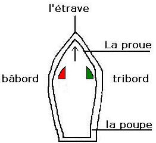

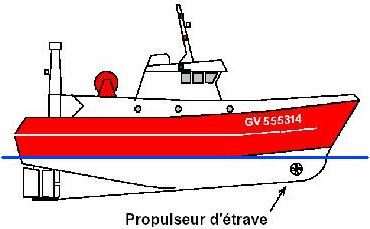

Le système est construit autour d’un ordinateur portable sur lequel est installé le système d’exploitation © Microsoft Windows Seven (ou Windows 8). Il intègre l’application « marine ».

Le bateau regroupe les équipements suivants :

- une centrale de pêche sur laquelle est reliée un GPS et un sondeur (mesure de profondeur)
- un module poupe (à l’arrière) sur lequel est relié le feu de poupe, une pompe de cale et les commandes manuelles du guindeau et de l’hélice d’étrave
- un module proue (à l’avant) sur lequel est relié une télécommande de guindeau, les feux de navigation bâbord et tribord, le guindeau et l’hélice d’étrave
- un pilote automatique

[figure not shown]

Les modules proue et poupe échangent des messages CAN avec le portable. Celui-ci nécessite donc une interface USB/CAN (MUX-DIAG de la société EXXOTEST).

Le pilote automatique communique en NMEA2000. On utilisera donc l’interface USB/CAN (MUX-DIAG de la société EXXOTEST).

La centrale de pêche communique en respectant la spécification NMEA 0183 et elle est reliée au portable via une interface USB/RS422 (Miniplex).

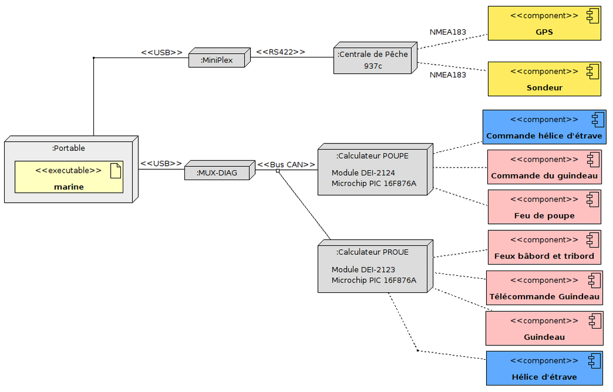

*Remarque :* la centrale de pêche peut être remplacé par un simple récepteur GPS.

Le diagramme (partiel) des cas d’utilisation est le suivant :

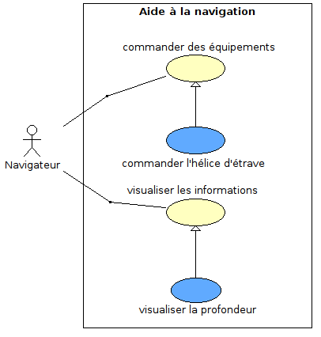

L’acteur humain de ce système est :

| Acteur | Rôle |
| --- | --- |
| Navigateur | Personne qui intervient sur le bateau lorsqu’il est à quai ou en mer. Il commande des équipements (hélice d’étrave, …). Il visualise en temps réel de l’ensemble des informations du système. |

## Contraintes d’environnement

| Ressource | Version |
| --- | --- |
| OS | Microsoft Windows (Seven ou 8) |
| EDI | Qt Creator |
| Compilateur | MinGW |
| API GUI | Qt 5.7 |

## Manuel d’installation

- Installer l’interface MUXDIAG
- Exécuter le programme setup pour installer l’application « marine ».
- Configurer le fichier `marine.ini` :

```
[marine]
; période d'acquisition des mesures en millisecondes
periode=1000
; exporte les mesures (on/off)
enregistrement=on
; n x 1/periode
frequenceEnregistrement=10
; format exportation des mesures (seul le csv est géré dans cette version)
format=csv
; efface le contenu du fichier au démarrage (on/off)
purge=on

[csv]
; choix des données à exporter
horodatage=true
temperatureEau=true
temperatureAir=true
vitesseBateau=true
vitesseVent=true
; seuil de détection du vent (en dessous la direction n'est pas prise en compte)
seuilVent=0.5
directionVent=true
localisation=true
; insertion d'un entête pour les données exportées
entete=true

[messagerie]
; les identifiants des messages CAN en décimal
; messagerie CAN HS DEI-211x.pdf
idVent=289
idTemperatureAir=288
idTemperatureEau=304
idVitesseBateau=305
idEnergieCentraleAlim=272
; DEI-2123.pdf
idCommandeProue=561
idCommandeGuindeau=565
idEnergieProue=563
idEtatProue=562
; DEI-2124.pdf
idCommandePoupe=577
idEnergiePoupe=579
idEtatPoupe=578
idCommandeHelice=581
; les PGN des messages NMEA2000 en décimal
; Pilote automatique SIMRAD AP16
pgnHeadingTrackControl=127237
pgnRudder=127245
pgnVesselHeading=127250
; adresse du périphérique NMEA2000
adressePiloteAuto=0

[gps]
; périphérique gps ou centrale de pêche
port=COM4
debit=9600
; préfixe de la phrase NMEA0183
;prefixe=IN
prefixe=GP
; type de phrase NMEA0183
profondeur=DPT
;localisation=RMC
localisation=GGA
; rien ou gpx (format kml non supporté dans cette version)
export=gpx

[buscan]
; muxdiag ou pcan (pcan non supporté dans cette version)
interface=muxdiag
; en bits/s (cf. nortme NMEA2000)
debit=250000
; message CAN : std (standard) ou ext (étendu)
type=ext
; numero de bus (pour muxdiag, 0 -> prise CAN HS1 ...)
adresse=0
; détection absence des données en ms (-1 pour infini)
timeout=1000
```

*Remarque :* normalement les fichiers créés (`marine.log`, `marine.csv` et/ou `marine.gpx`) par l’application sont stockés dans le répertoire d’installation de l’application. Mais, suivant vos droits, il est possible que les fichiers soient stockés dans `C:\Users\%USER\AppData\Local\VirtualStore\Program Files\Marine` (remplacer `%USER` par votre nom d’utilisateur).

## Manuel d’utilisation

L’application supervise l’ensemble des appareils connectés et permet leur commande :

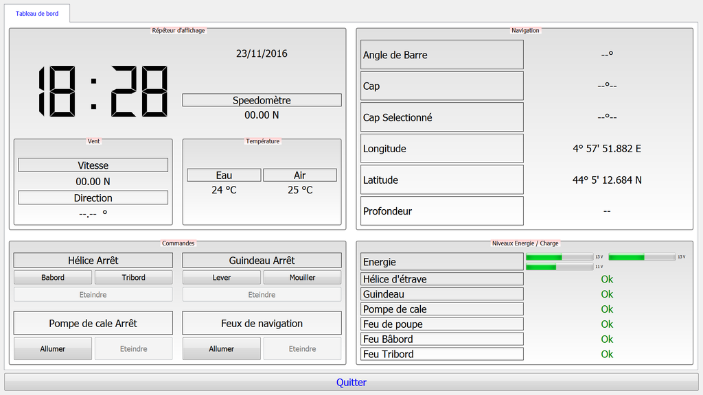

- En cas de défaut de communication NMEA0183 :

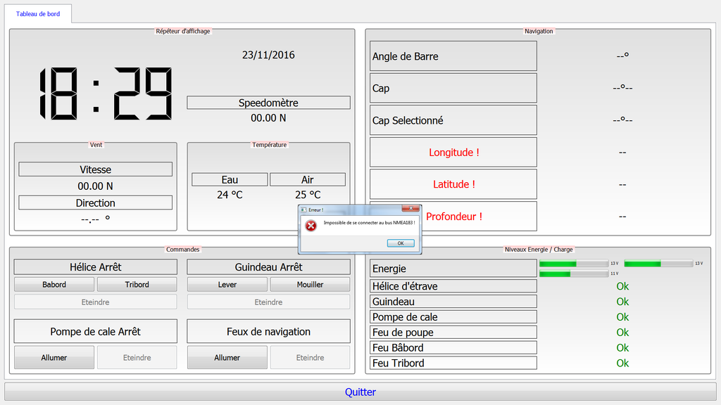

- En cas de défaut de communication BusCAN/NMEA2000 :

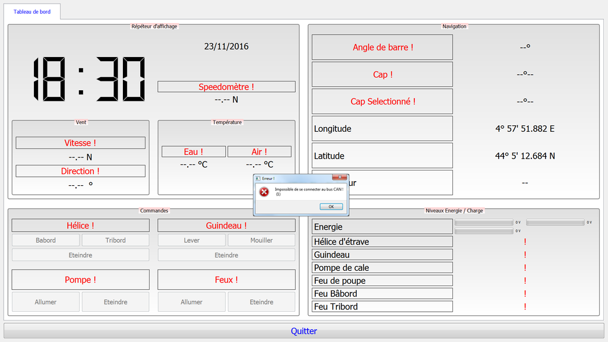

```
L'application consigne des messages, évènements, avertissements et erreurs dans un journal de log.
```

## Glossaire

- GPS (*Global Positioning Système*) : cet appareil permet de connaître en tout point du globe sa longitude et sa latitude et donc de se situer avec une précision inférieure à 100m. Les modèles les plus perfectionnés permettent également de saisir des points de route (points de passage obligés), indiquent le cap à suivre pour atteindre le point de route, la vitesse par rapport au fond, la distance parcourue, et possèdent une fonction « homme à la mer » qui mémorise les coordonnées du point de chute.
- Speedomètre: il mesure la vitesse du bateau par rapport à l’eau.
- Loch : il totalise les indications du speedomètre pour indiquer la distance parcourue par rapport à l’eau.
- Sondeur : il indique la hauteur de fond et, pour les modèles perfectionnés, dessine le relief du fond et localise les bancs de poissons.
- Anémomètre : il mesure la vitesse du vent apparent. Le vent apparent est le vent par rapport au bateau. Il dépend donc du vent réel et de la vitesse du bateau.
- Girouette : elle indique la direction du vent apparent par rapport à l’axe longitudinal du bateau.
- Compas : il indique le cap suivi par le bateau. Il s’agit le plus souvent du cap magnétique, mais il peut intégrer la correction nécessaire pour donner le cap géographique.
- Pilote automatique : il agit sur la barre pour conserver soit le cap, soit l’allure du bateau. L’allure est la direction du bateau par rapport à la direction du vent apparent.
- Détecteur d’homme à la mer : il est constitué d’un appareil, de petite dimension et généralement attaché à la ceinture des marins, qui envoie un signal radio lorsqu’il est immergé et d’un récepteur qui donne l’alarme lorsqu’il reçoit le signal. Il peut être interfacé avec le GPS qui enregistrera alors les coordonnées géographiques du point de chute et avec le pilote automatique qui fera alors stopper le bateau soit en lui faisant faire des ronds concentriques, soit en le plaçant à la cape (face au vent).
- Répétiteur d’affichage : il visualise les principales informations : cap, vitesse et direction du vent apparent et réel, profondeur de fond, vitesse en surface et vitesse fond…
- Lecteur de carte : il permet d’extraire les cartes marines contenue dans des «cartouches mémoires » ou sur CDROM. Il peut être couplé avec le radar et le GPS pour afficher automatiquement la carte du secteur où le bateau se trouve.
- Radar anti-collision: il permet de visualiser les navires circulant à proximité mais aussi le relief des côtes. Il est très utile pour la navigation de nuit, dans la brume ou en solitaire lorsqu’il n’y a pas toujours un homme de quart.
- VHF : c’est une radio émettant dans la bande VHF qui permet de communiquer avec d’autres navires, avec les capitaineries des ports, avec les organismes de sauvetage en mer. Certains modèles possèdent un dispositif d’envoi automatique de signal de détresse en transmettant dans ce cas les coordonnées géographiques du bateau issues du GPS.
- GPX (*GPS eXchange Format*) : c’est un format de fichier XML permettant l’échange de coordonnées GPS. Ce format permet de décrire une collection de points utilisables sous forme de point de cheminement (*waypoint*), trace (*track*) ou itinéraire (*route*). C’est un format de fichier ouvert.

## Activités

- Matériels : Modules PROUE/POUPE, Pilote automatique et Centrale de pêche
- Interfaces de communication : MUX-DIAG
- Bus de terrain : CAN/NMEA2000
- Réseau : aucun
- Fichiers : LOG, INI, CSV et GPX
- Autre(s) : PHP

Liste :

- Les fichiers LOG : 3h
- Les fichiers INI : 3h
- Les fichiers CSV : 3h
- Les fichiers GPX : 1h
- Application web : 8h
- Modules PROUE/POUPE : 6h
- Pilote automatique : 3h
- Centrale de pêche : 2h
- MUX-DIAG : 2h

Retour au sommaire